# Lab 3: MATH 4753

January 28, 2019

# Task 1

WD

```r
getwd()
```

```
## [1] "C:/Users/dyowe/Documents/RPackages/FALL224753yowe0004/Labs/Lab3"
```

# Task 2

### Read SPRUCE.csv into data frame spruce.df and print head

```r
spruce.df = read.csv("SPRUCE.csv")
head(spruce.df)
```

```
##   BHDiameter Height
## 1       18.9   20.0
## 2       16.6   18.8
## 3       15.5   16.8
## 4       15.5   16.9
## 5       19.4   20.2
## 6       13.7   16.3
```

# Task 3

### Make a scatter plot of spruce.df.

```r
plot(Height~BHDiameter, main="Daniel Yowell - Task 3 Scatter Plot", data = spruce.df, pch=21, bg="Blue", cex=1.2, xlim = c(0,1.1*max(BHDiameter)), ylim = c(0,1.1*max(Height)))

spruce.lm = lm(Height~BHDiameter, data = spruce.df)
summary(spruce.lm)
```

```
##
## Call:
## lm(formula = Height ~ BHDiameter, data = spruce.df)
##
## Residuals:
##     Min      1Q  Median      3Q     Max
## -3.9394 -0.9763  0.2829  0.9950  2.6644
##
## Coefficients:
##             Estimate Std. Error t value Pr(>|t|)
## (Intercept)  9.14684    1.12131   8.157 1.63e-09 ***
## BHDiameter   0.48147    0.05967   8.069 2.09e-09 ***
## ---
## Signif. codes:  0 '***' 0.001 '**' 0.01 '*' 0.05 '.' 0.1 ' ' 1
##
## Residual standard error: 1.678 on 34 degrees of freedom
## Multiple R-squared:  0.6569, Adjusted R-squared:  0.6468
## F-statistic:  65.1 on 1 and 34 DF,  p-value: 2.089e-09
```

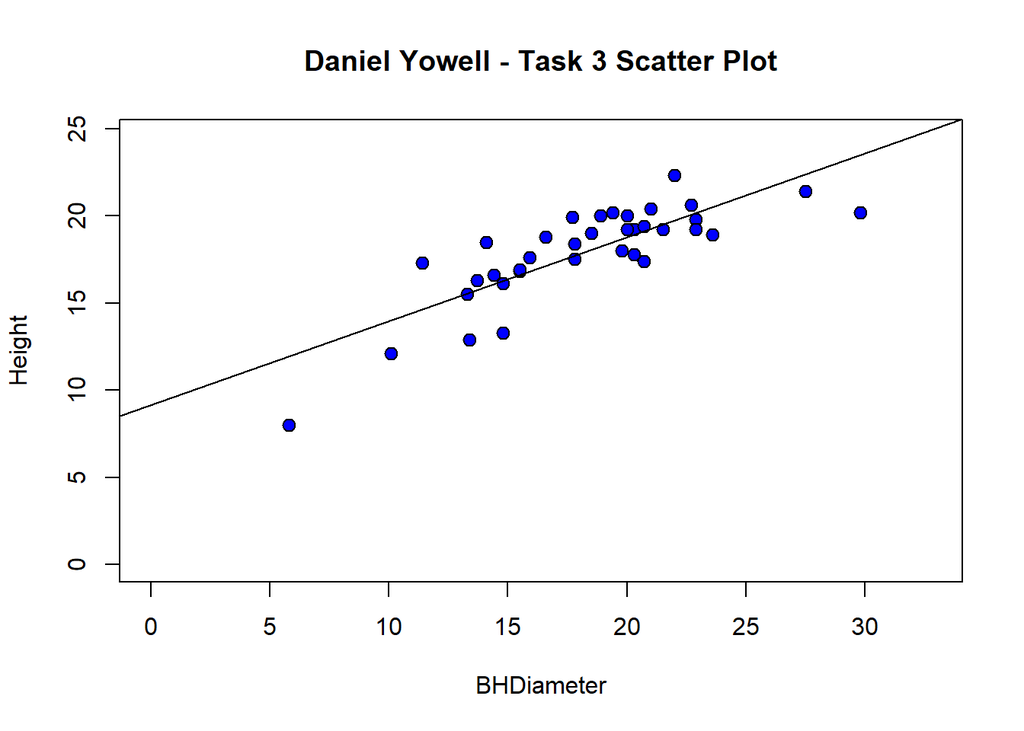

```r
abline(spruce.lm)
```

### Load the library s20x and make a lowess smoother scatter plot using trendscatter() (try a few values of f, f=0.5,0.6,0.7) record all three plots, use layout().

```r
library(s20x)
lo = layout(matrix(1:4, nr = 2, nc = 2, byrow = TRUE))

a <- trendscatter(Height~BHDiameter, data = spruce.df, f=0.5)
b <- trendscatter(Height~BHDiameter, data = spruce.df, f=0.6)
c <- trendscatter(Height~BHDiameter, data = spruce.df, f=0.7)
```

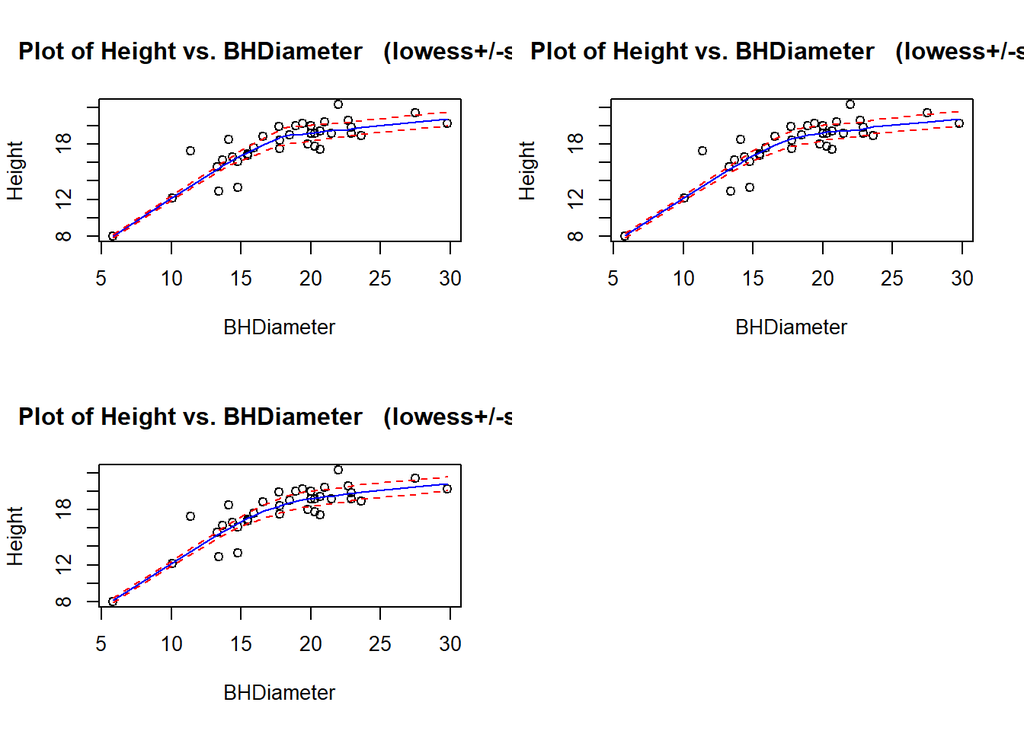

### We will assume (this may in fact be a bad assumption) a straight line relationship, use lm and make a linear model object, call it spruce.lm ### Make a new scatter plot and add the least squares regression line to the points - abline(spruce.lm) – record the plot. ### Comment on the graph, is a straight line appropriate? Consider the smoother curve also.

```r
spruce.lm = lm(Height~BHDiameter, data = spruce.df)
summary(spruce.lm)
```

```
##
## Call:
## lm(formula = Height ~ BHDiameter, data = spruce.df)
##
## Residuals:
##     Min      1Q  Median      3Q     Max
## -3.9394 -0.9763  0.2829  0.9950  2.6644
##
## Coefficients:
##             Estimate Std. Error t value Pr(>|t|)
## (Intercept)  9.14684    1.12131   8.157 1.63e-09 ***
## BHDiameter   0.48147    0.05967   8.069 2.09e-09 ***
## ---
## Signif. codes:  0 '***' 0.001 '**' 0.01 '*' 0.05 '.' 0.1 ' ' 1
##
## Residual standard error: 1.678 on 34 degrees of freedom
## Multiple R-squared:  0.6569, Adjusted R-squared:  0.6468
## F-statistic:  65.1 on 1 and 34 DF,  p-value: 2.089e-09
```

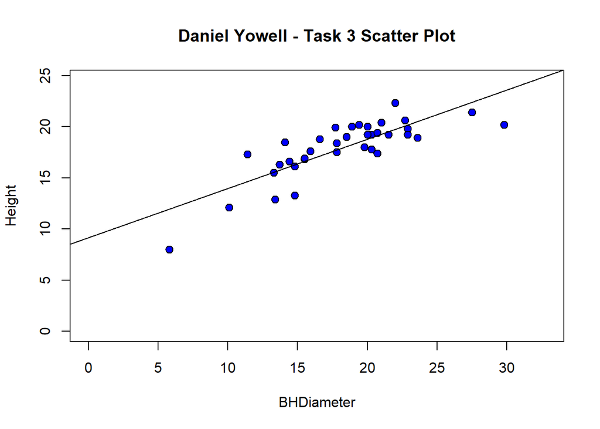

```r
plot(Height~BHDiameter, main="Daniel Yowell - Task 3 Scatter Plot", data = spruce.df, pch=21, bg="Blue", cex=1.2, xlim = c(0,1.1*max(BHDiameter)), ylim = c(0,1.1*max(Height)))
abline(spruce.lm)
```

The straight line is not the most accurate representation of the trend in this plot.

# Task 4

### - In the first square, plot the scatter plot and fitted line.

### - In the second square plot the same with the residual line segments (deviations about the fitted line). (RSS=residual sum of squares)

### - In the third square plot the mean of Y versus X i.e. mean of Height vs BHDiameter, with the fitted line and deviations of the fitted line from the mean height added. (MSS=model sum of squares)

### - In the fourth square plot the mean of Height versus BHDiameter and show the total deviation line segments ={y}. (TSS=total sum of squares)

```r
layout(matrix(1:4, nr = 2, nc = 2, byrow = TRUE))


a <- plot(Height~BHDiameter, main="Daniel Yowell - Original Plot", data = spruce.df, pch=21, bg="Blue", cex=1.2, xlim = c(0,1.1*max(BHDiameter)), ylim = c(0,1.1*max(Height)))
abline(spruce.lm)
# RSS
residuals <- resid(spruce.lm)
rss <- sum(residuals^2)

with(spruce.df,
     plot(Height~BHDiameter,bg="Blue",pch=21,ylim=c(0,1.1*max(Height)),xlim=c(0,1.1*max(BHDiameter)),main="Daniel Yowell - RSS Plot")
)

#make yhat the estimates of E[Height | BHDiameter]
yhat=with(spruce.df,predict(spruce.lm,data.frame(BHDiameter)))

# Draw in segments making the residuals (regression deviations)
with(spruce.df,{
  segments(BHDiameter,Height,BHDiameter,yhat)
})
abline(spruce.lm)

#residual sum of squares
RSS=with(spruce.df,sum((Height-yhat)^2))

RSS
```

```
## [1] 95.70281
```

```r
# MSS
with(spruce.df,
     plot(Height~BHDiameter,bg="Blue",pch=21,ylim=c(0,1.1*max(Height)),xlim=c(0,1.1*max(BHDiameter)),main="Daniel Yowell - MSS Plot")
)

#make nieve model
with(spruce.df, abline(h=mean(Height)))
abline(spruce.lm)

#make the explained deviations (explained by the model)
with(spruce.df, segments(BHDiameter,mean(Height),BHDiameter,yhat,col="Red"))
MSS=with(spruce.df,sum((yhat-mean(Height))^2))
MSS
```

```
## [1] 183.2447
```

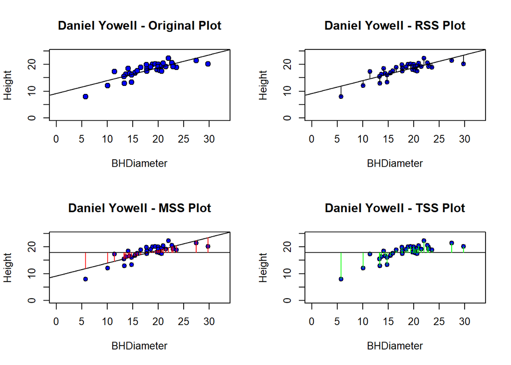

```r
# TSS
with(spruce.df,
     plot(Height~BHDiameter,bg="Blue",pch=21,ylim=c(0,1.1*max(Height)),xlim=c(0,1.1*max(BHDiameter)),main="Daniel Yowell - TSS Plot")
)
with(spruce.df,abline(h=mean(Height)))
with(spruce.df, segments(BHDiameter,Height,BHDiameter,mean(Height),col="Green"))
```

```r
TSS=with(spruce.df,sum((Height-mean(Height))^2))
TSS
```

```
## [1] 278.9475
```

```r
RSS + MSS
```

```
## [1] 278.9475
```

```r
#Can you find this number in the summary info?
MSS/TSS
```

```
## [1] 0.6569146
```

```r
# layout.show()
```

### Calculate TSS, MSS and RSS

# Task 5

# Task 6

[figure not shown]